# q1

```python
import numpy as np
import pandas as pd
import os
import matplotlib.pyplot as plt
import seaborn as sns

from functions.linear_models import PCA_function, OLS_regression
from functions.number_PC import rule_thumb, informal_way, biggest_drop
```

```python
# hide warning messages
import warnings
warnings.filterwarnings("ignore")
```

```python
# better plots
sns.set(rc={'figure.figsize':(12,8)});
```

```python
directory = os.path.dirname(os.getcwd())
directory
```

```
'd:\\github\\AssignmentEconometricsIV'
```

## Question

The first question consists of a factor analysis of a large dataset. We consider monthly close-to- close excess returns from a cross-section of 9,456 firms traded in the New York Stock Exchange. The data starts on November 1991 and runs until December 2018. There are 326 monthly observations in total.

In addition to the returns we also consider 16 monthly factors:

- Market (MKT)
- Small-minus-Big (SMB)
- High-minus-Low (HML)
- Conservative-minus-Aggressive (CMA)
- Robust-minus-Weak (RMW)
- earning/price ratio (EP)
- cash-flow/price ratio (CFP)
- dividend/price ratio
- accruals (ACC)
- market beta (BETA)
- net share issues
- daily variance (RETVOL)
- daily idiosyncratic variance (IDIOVOL)
- 1-month momentum (MOM1)
- 36-month momentum (MOM36)

The dataset is organized as an excel file named `returns.xlsx`.

```python
input_path = f'{directory}\\data\\returns.xlsx'
df = pd.read_excel(input_path, index_col=0)
```

```python
df.head()
```

| dates | MKT | HML | SMB | MOM1 | MOM36 | ACC | BETA | CFP | CHCSHO | DY | ... | r_9447 | r_9448 | r_9449 | r_9450 | r_9451 | r_9452 | r_9453 | r_9454 | r_9455 | r_9456 |
| --- | --- | --- | --- | --- | --- | --- | --- | --- | --- | --- | --- | --- | --- | --- | --- | --- | --- | --- | --- | --- | --- |
| 1991-11-29 | -0.041264 | -0.028083 | 0.004779 | -0.007336 | -0.025496 | -0.013692 | 0.035433 | -0.015116 | -0.006771 | -0.001226 | ... | 0.0 | 0.0 | 0.0 | 0.0 | 0.0 | 0.0 | 0.0 | 0.0 | 0.0 | 0.0 |
| 1991-12-31 | 0.107984 | -0.022529 | -0.027366 | 0.010963 | -0.021188 | -0.027887 | -0.082499 | -0.032122 | -0.005893 | -0.037563 | ... | 0.0 | 0.0 | 0.0 | 0.0 | 0.0 | 0.0 | 0.0 | 0.0 | 0.0 | 0.0 |
| 1992-01-31 | -0.007668 | 0.051012 | 0.085547 | 0.050916 | 0.108588 | 0.021978 | -0.072801 | 0.028117 | -0.008193 | -0.014228 | ... | 0.0 | 0.0 | 0.0 | 0.0 | 0.0 | 0.0 | 0.0 | 0.0 | 0.0 | 0.0 |
| 1992-02-28 | 0.010796 | 0.070501 | 0.002794 | -0.027398 | 0.079286 | 0.003860 | -0.024906 | 0.037363 | 0.015625 | 0.022895 | ... | 0.0 | 0.0 | 0.0 | 0.0 | 0.0 | 0.0 | 0.0 | 0.0 | 0.0 | 0.0 |
| 1992-03-31 | -0.025367 | 0.039029 | -0.015135 | -0.009367 | 0.024631 | 0.004612 | 0.041266 | 0.037916 | 0.017117 | 0.046819 | ... | 0.0 | 0.0 | 0.0 | 0.0 | 0.0 | 0.0 | 0.0 | 0.0 | 0.0 | 0.0 |

5 rows × 9472 columns

```python
factors_name = df.columns[:16]
factors_name
```

```
Index(['MKT', 'HML', 'SMB', 'MOM1', 'MOM36', 'ACC', 'BETA', 'CFP', 'CHCSHO',
       'DY', 'EP', 'IDIOVOL', 'CMA', 'UMD', 'RMW', 'RETVOL'],
      dtype='object')
```

```python
factors = df[factors_name]
factors.head()
```

| dates | MKT | HML | SMB | MOM1 | MOM36 | ACC | BETA | CFP | CHCSHO | DY | EP | IDIOVOL | CMA | UMD | RMW | RETVOL |
| --- | --- | --- | --- | --- | --- | --- | --- | --- | --- | --- | --- | --- | --- | --- | --- | --- |
| 1991-11-29 | -0.041264 | -0.028083 | 0.004779 | -0.007336 | -0.025496 | -0.013692 | 0.035433 | -0.015116 | -0.006771 | -0.001226 | 0.001586 | 0.036246 | -0.014193 | 0.012468 | -0.005361 | 0.026900 |
| 1991-12-31 | 0.107984 | -0.022529 | -0.027366 | 0.010963 | -0.021188 | -0.027887 | -0.082499 | -0.032122 | -0.005893 | -0.037563 | -0.008621 | -0.042074 | -0.003394 | 0.079571 | 0.032935 | -0.029811 |
| 1992-01-31 | -0.007668 | 0.051012 | 0.085547 | 0.050916 | 0.108588 | 0.021978 | -0.072801 | 0.028117 | -0.008193 | -0.014228 | -0.006754 | -0.089817 | 0.019346 | -0.026594 | 0.005965 | -0.076449 |
| 1992-02-28 | 0.010796 | 0.070501 | 0.002794 | -0.027398 | 0.079286 | 0.003860 | -0.024906 | 0.037363 | 0.015625 | 0.022895 | 0.016494 | -0.012679 | 0.022658 | -0.005968 | 0.017131 | -0.021424 |
| 1992-03-31 | -0.025367 | 0.039029 | -0.015135 | -0.009367 | 0.024631 | 0.004612 | 0.041266 | 0.037916 | 0.017117 | 0.046819 | 0.032956 | 0.060565 | 0.025606 | -0.003624 | -0.013689 | 0.027512 |

```python
returns_name = df.columns[16:]
returns_name
```

```
Index(['r_   1', 'r_   2', 'r_   3', 'r_   4', 'r_   5', 'r_   6', 'r_   7',
       'r_   8', 'r_   9', 'r_  10',
       ...
       'r_9447', 'r_9448', 'r_9449', 'r_9450', 'r_9451', 'r_9452', 'r_9453',
       'r_9454', 'r_9455', 'r_9456'],
      dtype='object', length=9456)
```

```python
returns = df[returns_name]
returns.head()
```

| dates | r_ 1 | r_ 2 | r_ 3 | r_ 4 | r_ 5 | r_ 6 | r_ 7 | r_ 8 | r_ 9 | r_ 10 | ... | r_9447 | r_9448 | r_9449 | r_9450 | r_9451 | r_9452 | r_9453 | r_9454 | r_9455 | r_9456 |
| --- | --- | --- | --- | --- | --- | --- | --- | --- | --- | --- | --- | --- | --- | --- | --- | --- | --- | --- | --- | --- | --- |
| 1991-11-29 | 0.130715 | -0.053900 | -0.110696 | -0.043900 | 0.218322 | 0.050645 | 0.575047 | 0.008921 | -0.105349 | -0.034203 | ... | 0.0 | 0.0 | 0.0 | 0.0 | 0.0 | 0.0 | 0.0 | 0.0 | 0.0 | 0.0 |
| 1991-12-31 | -0.010580 | -0.056432 | 0.213591 | 0.183700 | 1.299230 | 0.306545 | 0.040644 | -0.003800 | 0.318781 | 0.178492 | ... | 0.0 | 0.0 | 0.0 | 0.0 | 0.0 | 0.0 | 0.0 | 0.0 | 0.0 | 0.0 |
| 1992-01-31 | -0.055124 | -0.003400 | -0.164114 | -0.205154 | -0.082347 | 0.075547 | -0.024677 | -0.066691 | 0.155137 | 0.071490 | ... | 0.0 | 0.0 | 0.0 | 0.0 | 0.0 | 0.0 | 0.0 | 0.0 | 0.0 | 0.0 |
| 1992-02-28 | -0.202800 | 5.219422 | 0.039753 | -0.057745 | -0.117086 | 0.204517 | -0.089757 | -0.083881 | 0.018253 | 0.128348 | ... | 0.0 | 0.0 | 0.0 | 0.0 | 0.0 | 0.0 | 0.0 | 0.0 | 0.0 | 0.0 |
| 1992-03-31 | 0.078418 | -0.181971 | -0.023808 | 0.043112 | 0.415955 | 0.064782 | -0.146257 | -0.179871 | -0.209586 | -0.173690 | ... | 0.0 | 0.0 | 0.0 | 0.0 | 0.0 | 0.0 | 0.0 | 0.0 | 0.0 | 0.0 |

5 rows × 9456 columns

```python
daterange = returns.index
daterange
```

```
DatetimeIndex(['1991-11-29', '1991-12-31', '1992-01-31', '1992-02-28',
               '1992-03-31', '1992-04-30', '1992-05-29', '1992-06-30',
               '1992-07-31', '1992-08-31',
               ...
               '2018-03-29', '2018-04-30', '2018-05-31', '2018-06-29',
               '2018-07-31', '2018-08-31', '2018-09-28', '2018-10-31',
               '2018-11-30', '2018-12-31'],
              dtype='datetime64[ns]', name='dates', length=326, freq=None)
```

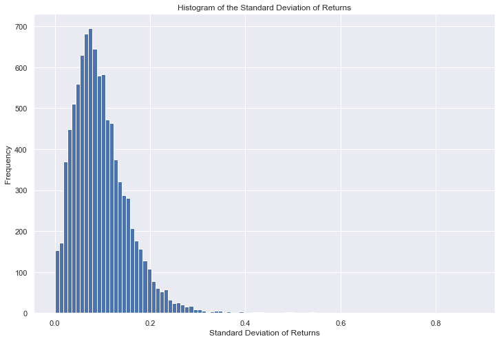

```python
plt.hist(returns.std(axis=0), bins=100)
plt.xlabel('Standard Deviation of Returns')
plt.ylabel('Frequency')
plt.title('Histogram of the Standard Deviation of Returns');
```

```python
standardized_returns = (returns - returns.mean(axis=0))/returns.std(axis=0)
standardized_returns.head()
```

| dates | r_ 1 | r_ 2 | r_ 3 | r_ 4 | r_ 5 | r_ 6 | r_ 7 | r_ 8 | r_ 9 | r_ 10 | ... | r_9447 | r_9448 | r_9449 | r_9450 | r_9451 | r_9452 | r_9453 | r_9454 | r_9455 | r_9456 |
| --- | --- | --- | --- | --- | --- | --- | --- | --- | --- | --- | --- | --- | --- | --- | --- | --- | --- | --- | --- | --- | --- |
| 1991-11-29 | 1.483764 | -0.219996 | -0.914187 | -0.665776 | 1.031984 | 0.207163 | 3.474317 | -0.028135 | -0.775232 | -0.357849 | ... | -0.129987 | -0.057779 | -0.060114 | -0.153584 | 0.054239 | 0.063002 | -0.040374 | 0.014576 | 0.014591 | -0.126962 |
| 1991-12-31 | -0.223389 | -0.226904 | 1.435410 | 2.066812 | 6.526489 | 1.869218 | 0.235135 | -0.125593 | 2.076082 | 1.415134 | ... | -0.129987 | -0.057779 | -0.060114 | -0.153584 | 0.054239 | 0.063002 | -0.040374 | 0.014576 | 0.014591 | -0.126962 |
| 1992-01-31 | -0.761584 | -0.082197 | -1.301224 | -2.601812 | -0.496389 | 0.368900 | -0.160796 | -0.607431 | 0.975946 | 0.523187 | ... | -0.129987 | -0.057779 | -0.060114 | -0.153584 | 0.054239 | 0.063002 | -0.040374 | 0.014576 | 0.014591 | -0.126962 |
| 1992-02-28 | -2.545832 | 14.169328 | 0.175881 | -0.832001 | -0.672972 | 1.206552 | -0.555266 | -0.739131 | 0.055711 | 0.997142 | ... | -0.129987 | -0.057779 | -0.060114 | -0.153584 | 0.054239 | 0.063002 | -0.040374 | 0.014576 | 0.014591 | -0.126962 |
| 1992-03-31 | 0.851900 | -0.569465 | -0.284648 | 0.378895 | 2.036596 | 0.298978 | -0.897734 | -1.474551 | -1.475986 | -1.520584 | ... | -0.129987 | -0.057779 | -0.060114 | -0.153584 | 0.054239 | 0.063002 | -0.040374 | 0.014576 | 0.014591 | -0.126962 |

5 rows × 9456 columns

```python
standardized_factors = (factors - factors.mean(axis=0))/factors.std(axis=0)
standardized_factors.head()
```

| dates | MKT | HML | SMB | MOM1 | MOM36 | ACC | BETA | CFP | CHCSHO | DY | EP | IDIOVOL | CMA | UMD | RMW | RETVOL |
| --- | --- | --- | --- | --- | --- | --- | --- | --- | --- | --- | --- | --- | --- | --- | --- | --- |
| 1991-11-29 | -1.146021 | -0.942950 | 0.110054 | -0.298999 | -0.981611 | -0.855086 | 0.608329 | -0.530965 | -0.390990 | -0.079259 | -0.022967 | 0.643319 | -0.726929 | 0.173469 | -0.415524 | 0.463981 |
| 1991-12-31 | 2.438375 | -0.768570 | -0.927363 | 0.228826 | -0.830584 | -1.573833 | -1.458119 | -1.015147 | -0.356068 | -0.565565 | -0.299827 | -0.753791 | -0.259791 | 1.590413 | 1.593428 | -0.591458 |
| 1992-01-31 | -0.339177 | 1.540227 | 2.716591 | 1.381237 | 3.719257 | 0.951073 | -1.288179 | 0.699949 | -0.447614 | -0.253274 | -0.249191 | -1.605470 | 0.723840 | -0.651357 | 0.178593 | -1.459412 |
| 1992-02-28 | 0.104274 | 2.152085 | 0.045976 | -0.877648 | 2.691977 | 0.033673 | -0.448956 | 0.963170 | 0.500523 | 0.243548 | 0.381386 | -0.229440 | 0.867106 | -0.215804 | 0.764371 | -0.435358 |
| 1992-03-31 | -0.764238 | 1.164027 | -0.532641 | -0.357583 | 0.775803 | 0.071737 | 0.710532 | 0.978913 | 0.559947 | 0.563717 | 0.827889 | 1.077129 | 0.994599 | -0.166317 | -0.852409 | 0.475367 |

The model

$$ \begin{aligned} Y_t & =\beta_0+\beta_1 X_{1 t}+\cdots+\beta_p X_{n t}+U_t, \quad t=1, \ldots, T \\ & =\boldsymbol{\beta}^{\prime} \boldsymbol{X}_t+U_t \\ \boldsymbol{Y} & =\boldsymbol{X} \boldsymbol{\beta}+\boldsymbol{U} \quad \text { (matrix notation). } \end{aligned} $$

However, $n>T$ (more columns than rows in $X$ ).

The usual ordinary least squares (OLS) solution $$ \widehat{\boldsymbol{\beta}}=\left(X^{\prime} X\right)^{-1} X^{\prime} Y $$ is not valid anymore.

Solution: reduce the dimension of $\boldsymbol{X}$ by postulating that:

$$ \underset{(n \times 1)}{\boldsymbol{X}_t}=\underset{(n \times k)}{\boldsymbol{\Lambda}} \underset{(k \times 1)}{\boldsymbol{F}_t}+\underset{(n \times 1)}{\boldsymbol{V}_t}, $$

where:

- $F_t$ is a set of $k<<n$ unobserved factors;
- $\boldsymbol{V}_t$ is the vector of idiosyncratic errors;
- $\boldsymbol{\Lambda}$ is the matrix of unobserved factor loadings.

### (a) (30 points)

Compute the principal components of the returns and determine the optimal number of principal factors by one the methods described in Lecture 2. How much of the variance will the factors be able to explain?

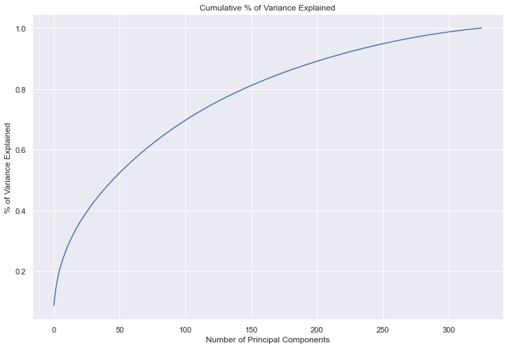

```python
pcs, gammas, lambdas, alphas = PCA_function(returns)
```

The transformed dataset containing only the first $k$ PCs is the $(T \times k)$ matrix is given by $$ \begin{aligned} Z_{(k)}&:=\boldsymbol{X} \boldsymbol{\Gamma}_k \\ &:=\left(Z_1, \ldots, Z_k\right) . \end{aligned} $$

```python
pcs
```

| dates | PC 1 | PC 2 | PC 3 | PC 4 | PC 5 | PC 6 | PC 7 | PC 8 | PC 9 | PC 10 | ... | PC 317 | PC 318 | PC 319 | PC 320 | PC 321 | PC 322 | PC 323 | PC 324 | PC 325 | PC 326 |
| --- | --- | --- | --- | --- | --- | --- | --- | --- | --- | --- | --- | --- | --- | --- | --- | --- | --- | --- | --- | --- | --- |
| 1991-11-29 | -0.932311 | 0.655585 | 0.023695 | -0.023417 | -0.126589 | 0.216290 | -0.287319 | 0.317324 | 0.367579 | -0.003083 | ... | 0.099741 | -0.147412 | -0.017165 | 0.039770 | -0.030666 | -0.305971 | -0.070527 | 0.105582 | -0.107813 | 4.735418e-16 |
| 1991-12-31 | 0.684426 | -0.766075 | 0.098573 | 0.101246 | 0.403129 | -0.197598 | 0.258110 | -0.600949 | -0.532293 | -0.198487 | ... | -0.056220 | -0.052040 | 0.049895 | -0.116038 | -0.000257 | -0.216104 | -0.019173 | 0.044938 | 0.046535 | 4.735418e-16 |
| 1992-01-31 | 2.223682 | -0.458117 | -0.226293 | -0.012401 | 0.090334 | -0.388412 | 0.722587 | -1.958945 | -1.086762 | -0.027658 | ... | 0.012034 | -0.102328 | 0.015964 | 0.057844 | -0.015542 | -0.043326 | -0.015525 | 0.020216 | 0.011105 | 4.735418e-16 |
| 1992-02-28 | 0.562873 | -0.140579 | 0.159400 | 0.006865 | 0.158465 | -0.255173 | 0.436401 | -0.784899 | -0.009006 | -0.100874 | ... | -0.081432 | -0.110698 | -0.007424 | 0.027146 | -0.009137 | 0.126851 | 0.036233 | -0.057103 | 0.000894 | 4.735418e-16 |
| 1992-03-31 | -0.743650 | 0.306019 | 0.224420 | -0.089483 | -0.141921 | 0.050060 | -0.242078 | 0.170550 | 0.233088 | 0.004558 | ... | -0.017391 | -0.038388 | -0.117780 | 0.005034 | -0.062418 | -0.106408 | -0.033974 | -0.035663 | -0.002988 | 4.735418e-16 |
| ... | ... | ... | ... | ... | ... | ... | ... | ... | ... | ... | ... | ... | ... | ... | ... | ... | ... | ... | ... | ... | ... |
| 2018-08-31 | 0.161871 | -0.265360 | -0.020674 | -0.097998 | 0.026575 | -0.056679 | -0.109673 | -0.051071 | 0.165194 | -0.118351 | ... | -0.029515 | 0.187625 | -0.124839 | 0.082496 | -0.793752 | 0.239586 | -0.181260 | 0.009889 | -0.084397 | 4.735418e-16 |
| 2018-09-28 | -0.942054 | 0.462936 | 0.124402 | -0.082200 | -0.051525 | 0.076335 | -0.044931 | 0.278179 | 0.381509 | 0.355261 | ... | -0.229286 | -0.734919 | 0.049653 | -0.526654 | 0.340547 | -0.242943 | 0.018376 | -0.267907 | 0.114492 | 4.735418e-16 |
| 2018-10-31 | -2.535630 | 2.642636 | -0.063295 | 0.056235 | 0.753975 | 0.545761 | -0.142676 | -0.170747 | 0.015823 | -0.070887 | ... | -0.562181 | -0.490485 | -0.060676 | -0.242340 | 1.202036 | -0.721417 | 0.795699 | 0.831066 | 0.851113 | 4.735418e-16 |
| 2018-11-30 | -0.418945 | 0.200803 | 0.180173 | 0.041064 | 0.087297 | 0.077100 | -0.050033 | 0.015725 | 0.007103 | -0.108428 | ... | -0.109041 | -0.054202 | -0.161460 | -0.010917 | 0.122621 | 0.058508 | 0.452031 | 0.140706 | -0.162255 | 4.735418e-16 |
| 2018-12-31 | -3.014504 | 3.133093 | -0.011031 | 0.038419 | 0.759613 | 0.698890 | -0.215036 | -0.120849 | 0.340362 | 0.126565 | ... | 0.436576 | 0.737837 | 0.078670 | 0.273152 | -0.505859 | 0.281901 | -1.444786 | -0.919381 | -0.822867 | 4.735418e-16 |

326 rows × 326 columns

Given the desired number of $\mathrm{PCs}$, say $1 \leq k \leq n$, we collect all the vectors $\gamma_1, \ldots \gamma_k$ in a $(n \times k)$ matrix $$ \Gamma_k:=\left(\gamma_1, \ldots \gamma_k\right) $$

```python
gammas
```

|  | gamma 1 | gamma 2 | gamma 3 | gamma 4 | gamma 5 | gamma 6 | gamma 7 | gamma 8 | gamma 9 | gamma 10 | ... | gamma 317 | gamma 318 | gamma 319 | gamma 320 | gamma 321 | gamma 322 | gamma 323 | gamma 324 | gamma 325 | gamma 326 |
| --- | --- | --- | --- | --- | --- | --- | --- | --- | --- | --- | --- | --- | --- | --- | --- | --- | --- | --- | --- | --- | --- |
| r_ 1 | 0.002032 | -0.002777 | -0.000804 | 0.000050 | 0.002960 | 0.001060 | -0.002195 | 0.001189 | 0.003266 | 0.001595 | ... | -0.055600 | -0.010719 | 0.010019 | -0.015780 | -0.027833 | 0.055534 | 0.003560 | 0.039098 | -0.035205 | 0.067707 |
| r_ 2 | 0.027143 | 0.015565 | -0.009166 | -0.002057 | 0.016365 | 0.000631 | 0.050304 | -0.038719 | 0.031042 | 0.008654 | ... | -0.012597 | -0.019896 | 0.001233 | 0.012640 | 0.003554 | 0.034309 | 0.016381 | -0.018323 | 0.001547 | 0.081315 |
| r_ 3 | 0.005195 | -0.013071 | -0.003946 | -0.000183 | -0.011596 | -0.007778 | 0.006669 | -0.008175 | -0.001616 | 0.001135 | ... | -0.012692 | -0.003509 | 0.012112 | -0.028283 | 0.015846 | -0.006557 | -0.021075 | -0.009064 | 0.003942 | 0.161300 |
| r_ 4 | 0.005707 | -0.010162 | -0.002122 | -0.000947 | 0.001569 | -0.003475 | 0.010309 | -0.008786 | -0.013182 | -0.000184 | ... | -0.004217 | -0.001040 | 0.023705 | -0.010965 | 0.003253 | -0.003623 | 0.006555 | 0.013706 | -0.000262 | 0.018544 |
| r_ 5 | 0.012439 | -0.006495 | -0.005756 | 0.003450 | 0.002966 | -0.002718 | 0.000583 | 0.010150 | -0.025101 | 0.019980 | ... | 0.060868 | 0.027539 | 0.013735 | 0.010794 | -0.013569 | -0.004256 | -0.013931 | -0.009588 | 0.020320 | 0.056703 |
| ... | ... | ... | ... | ... | ... | ... | ... | ... | ... | ... | ... | ... | ... | ... | ... | ... | ... | ... | ... | ... | ... |
| r_9452 | 0.000369 | -0.000801 | 0.000187 | 0.000163 | -0.000448 | -0.000325 | -0.000036 | 0.000097 | -0.000019 | 0.000160 | ... | -0.002082 | 0.011501 | 0.000467 | -0.000937 | 0.000679 | 0.001598 | 0.009070 | 0.005617 | 0.004264 | -0.000598 |
| r_9453 | -0.000875 | -0.000733 | 0.001381 | -0.001983 | -0.001478 | -0.002800 | -0.001009 | 0.006402 | 0.006902 | 0.004908 | ... | -0.002991 | 0.001648 | 0.012225 | -0.011894 | 0.000847 | 0.009313 | -0.007776 | 0.006292 | -0.022556 | 0.011186 |
| r_9454 | 0.000287 | -0.000691 | 0.000124 | 0.000281 | -0.000370 | -0.000841 | 0.000233 | -0.000081 | -0.000079 | 0.000179 | ... | -0.028882 | -0.003015 | -0.002117 | 0.008063 | 0.031630 | -0.005160 | 0.001834 | 0.028560 | -0.015476 | 0.000334 |
| r_9455 | 0.002324 | -0.005739 | 0.001035 | -0.000288 | -0.003415 | -0.003190 | 0.000175 | 0.002162 | 0.000171 | 0.000134 | ... | 0.002787 | 0.000656 | 0.008604 | -0.003572 | 0.010269 | -0.000765 | 0.006759 | -0.003467 | -0.009770 | -0.001784 |
| r_9456 | 0.001238 | -0.003543 | 0.000601 | -0.000469 | -0.002063 | -0.002022 | -0.000150 | 0.002713 | 0.001410 | 0.001234 | ... | -0.019777 | 0.017696 | 0.014970 | 0.026038 | 0.004847 | -0.019618 | 0.019659 | 0.018860 | -0.023323 | 0.000734 |

9456 rows × 326 columns

```python
# PCA function centered the data before to compute the PCs
centered_returns = (returns - returns.mean(axis=0))
centered_factors = (factors - factors.mean(axis=0))
```

```python
# just checking
sum(round(centered_returns.dot(np.array(gammas["gamma 1"])), 10) == round(pcs["PC 1"], 10))
```

```
326
```

Also, by construction, the columns of $Z_{(k)}$ (the PCs) are orthogonal random variables, and with sample variances $\lambda_1, \ldots, \lambda_k$.

Thus, the sample covariance matrix of $Z_{(k)}$ is given by the $(k \times k)$ diagonal matrix $$ \boldsymbol{\Lambda}_k:=\operatorname{diag}\left(\lambda_1, \ldots, \lambda_k\right) $$

```python
lambdas[:10]
```

```
array([10.59291481,  5.04991983,  3.33383555,  2.76500035,  2.40685564,
        1.94349613,  1.7572486 ,  1.61955915,  1.51600711,  1.45686289])
```

It is a good idea to start by running a full PCA $(k=n)$ and plotting the quantity $$ \alpha_j=\frac{\lambda_j}{\sum_{j=1}^n \lambda_j} $$ for $j \in\{1, \ldots, n\}$.

```python
alphas[:10]
```

```
array([0.0868341 , 0.04139609, 0.0273287 , 0.02266575, 0.0197299 ,
       0.01593157, 0.01440483, 0.01327614, 0.01242728, 0.01194245])
```

```python
Lambda = round(pcs.cov(), 2)
```

Also, by construction, the columns of $Z_{(k)}$ (the $\mathrm{PCs}$) are orthogonal random variables, and with sample variances $\lambda_1, \ldots, \lambda_k$. Thus, the sample covariance matrix of $Z_{(k)}$ is given by the $(k \times k)$ diagonal matrix $$ \boldsymbol{\Lambda}_k:=\operatorname{diag}\left(\lambda_1, \ldots, \lambda_k\right) . $$

```python
Lambda.head(10)[['PC 1', 'PC 2', 'PC 3', 'PC 4', 'PC 5', 'PC 6', 'PC 7', 'PC 8', 'PC 9', 'PC 10']]
```

|  | PC 1 | PC 2 | PC 3 | PC 4 | PC 5 | PC 6 | PC 7 | PC 8 | PC 9 | PC 10 |
| --- | --- | --- | --- | --- | --- | --- | --- | --- | --- | --- |
| PC 1 | 10.59 | 0.00 | 0.00 | 0.00 | 0.00 | 0.00 | -0.00 | -0.00 | -0.00 | 0.00 |
| PC 2 | 0.00 | 5.05 | -0.00 | -0.00 | 0.00 | -0.00 | 0.00 | -0.00 | -0.00 | 0.00 |
| PC 3 | 0.00 | -0.00 | 3.33 | 0.00 | -0.00 | 0.00 | 0.00 | -0.00 | -0.00 | 0.00 |
| PC 4 | 0.00 | -0.00 | 0.00 | 2.77 | 0.00 | 0.00 | -0.00 | 0.00 | -0.00 | 0.00 |
| PC 5 | 0.00 | 0.00 | -0.00 | 0.00 | 2.41 | -0.00 | 0.00 | 0.00 | 0.00 | 0.00 |
| PC 6 | 0.00 | -0.00 | 0.00 | 0.00 | -0.00 | 1.94 | 0.00 | 0.00 | -0.00 | -0.00 |
| PC 7 | -0.00 | 0.00 | 0.00 | -0.00 | 0.00 | 0.00 | 1.76 | 0.00 | 0.00 | 0.00 |
| PC 8 | -0.00 | -0.00 | -0.00 | 0.00 | 0.00 | 0.00 | 0.00 | 1.62 | -0.00 | -0.00 |
| PC 9 | -0.00 | -0.00 | -0.00 | -0.00 | 0.00 | -0.00 | 0.00 | -0.00 | 1.52 | -0.00 |
| PC 10 | 0.00 | 0.00 | 0.00 | 0.00 | 0.00 | -0.00 | 0.00 | -0.00 | -0.00 | 1.46 |

```python
lambdas[:10]
```

```
array([10.59291481,  5.04991983,  3.33383555,  2.76500035,  2.40685564,
        1.94349613,  1.7572486 ,  1.61955915,  1.51600711,  1.45686289])
```

#### Rule of Thumb

Stop at a $k$ such that the $(k+1)$-th PC does not add much to the already explained variance (say $<3 \%$ ).

```python
n_pc_rt = rule_thumb(alphas)
```

```
The first 2 PCs explain 12.82% of the returns variance.
```

#### Informal Way

Choose the number of components such that a large portion (say 90\%) of the variance is explained.

```python
n_pc_iw = informal_way(alphas)
```

```
The first 207 PCs explain 89.91% of the returns variance.
```

#### Biggest Drop

Onatski (2010) suggests looking for the biggest drop computing $$ r:=\arg \max _{1 \leq j<n} \frac{\lambda_j}{\lambda_{j+1}} . $$

```python
n_pc_bd = biggest_drop(lambdas)
```

```
The first 1 PCs explain 8.68% of the returns variance.
```

### (b) (30 points)

Regress the selected factors on the 16 observed "anomaly" factors described above. How do the "principal component factors" relate to the "anomaly factors"?

```python
# rule of thumb
pc_ret_rt = pcs.iloc[:,:n_pc_rt]
pc_ret_rt.head()
```

| dates | PC 1 | PC 2 |
| --- | --- | --- |
| 1991-11-29 | -0.932311 | 0.655585 |
| 1991-12-31 | 0.684426 | -0.766075 |
| 1992-01-31 | 2.223682 | -0.458117 |
| 1992-02-28 | 0.562873 | -0.140579 |
| 1992-03-31 | -0.743650 | 0.306019 |

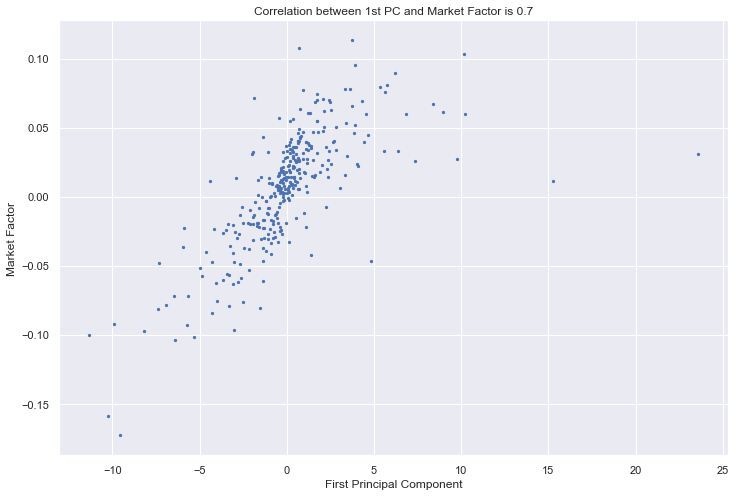

```python
corr = round(factors['MKT'].corr(pc_ret_rt['PC 1']), 2)
plt.scatter(pc_ret_rt['PC 1'], factors['MKT'], s=5)
plt.xlabel('First Principal Component')
plt.ylabel('Market Factor')
plt.title(f'Correlation between 1st PC and Market Factor is {corr}');
```

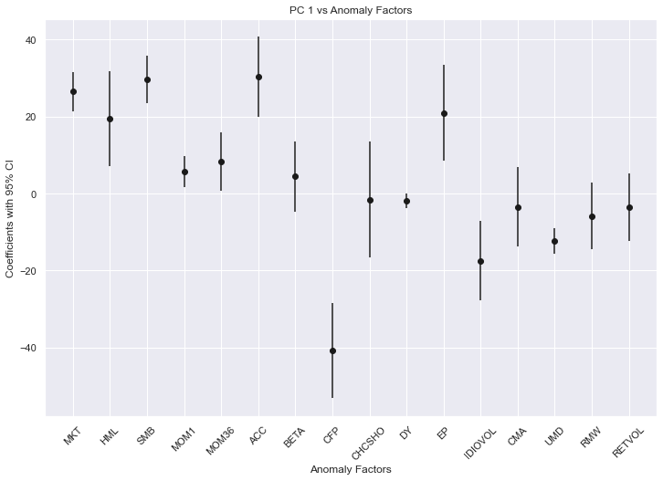

```python
pc1 = OLS_regression(y = pc_ret_rt, X = factors, y_column = "PC 1", is_pc = False)
```

```python
print(pc1.summary())
```

```
                            OLS Regression Results
==============================================================================
Dep. Variable:                   PC 1   R-squared:                       0.878
Model:                            OLS   Adj. R-squared:                  0.872
Method:                 Least Squares   F-statistic:                     139.3
Date:                Sat, 15 Jul 2023   Prob (F-statistic):          1.04e-130
Time:                        16:35:49   Log-Likelihood:                -503.55
No. Observations:                 326   AIC:                             1041.
Df Residuals:                     309   BIC:                             1105.
Df Model:                          16
Covariance Type:            nonrobust
==============================================================================
                 coef    std err          t      P>|t|      [0.025      0.975]
------------------------------------------------------------------------------
const         -0.1940      0.074     -2.629      0.009      -0.339      -0.049
MKT           26.4644      2.614     10.123      0.000      21.321      31.608
HML           19.4347      6.242      3.114      0.002       7.153      31.717
SMB           29.7067      3.142      9.455      0.000      23.524      35.889
MOM1           5.6690      2.073      2.734      0.007       1.589       9.749
MOM36          8.2647      3.877      2.131      0.034       0.635      15.894
ACC           30.3074      5.272      5.748      0.000      19.933      40.682
BETA           4.4525      4.636      0.960      0.338      -4.670      13.575
CFP          -40.7554      6.249     -6.522      0.000     -53.051     -28.460
CHCSHO        -1.5690      7.657     -0.205      0.838     -16.636      13.498
DY            -1.9132      1.005     -1.903      0.058      -3.891       0.065
EP            20.9376      6.344      3.301      0.001       8.455      33.420
IDIOVOL      -17.4350      5.192     -3.358      0.001     -27.652      -7.218
CMA           -3.4515      5.189     -0.665      0.506     -13.662       6.759
UMD          -12.2663      1.692     -7.250      0.000     -15.595      -8.937
RMW           -5.8582      4.399     -1.332      0.184     -14.514       2.798
RETVOL        -3.6166      4.429     -0.817      0.415     -12.331       5.097
==============================================================================
Omnibus:                      186.517   Durbin-Watson:                   1.791
Prob(Omnibus):                  0.000   Jarque-Bera (JB):             3153.860
Skew:                           1.974   Prob(JB):                         0.00
Kurtosis:                      17.717   Cond. No.                         147.
==============================================================================

Notes:
[1] Standard Errors assume that the covariance matrix of the errors is correctly specified.
```

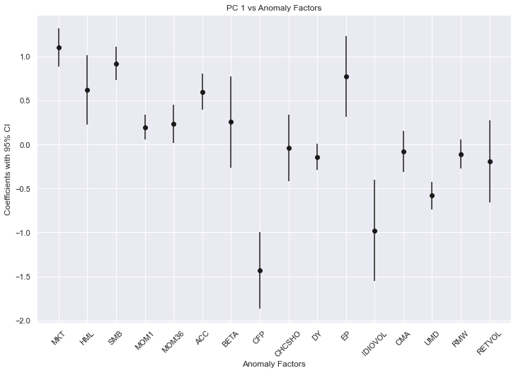

```python
pc1std = OLS_regression(y = pc_ret_rt, X = standardized_factors, y_column = "PC 1", is_pc = False)
```

```python
print(pc1std.summary())
```

```
                            OLS Regression Results
==============================================================================
Dep. Variable:                   PC 1   R-squared:                       0.878
Model:                            OLS   Adj. R-squared:                  0.872
Method:                 Least Squares   F-statistic:                     139.3
Date:                Sat, 15 Jul 2023   Prob (F-statistic):          1.04e-130
Time:                        16:35:50   Log-Likelihood:                -503.55
No. Observations:                 326   AIC:                             1041.
Df Residuals:                     309   BIC:                             1105.
Df Model:                          16
Covariance Type:            nonrobust
==============================================================================
                 coef    std err          t      P>|t|      [0.025      0.975]
------------------------------------------------------------------------------
const      -1.162e-16      0.065   -1.8e-15      1.000      -0.127       0.127
MKT            1.1019      0.109     10.123      0.000       0.888       1.316
HML            0.6190      0.199      3.114      0.002       0.228       1.010
SMB            0.9205      0.097      9.455      0.000       0.729       1.112
MOM1           0.1965      0.072      2.734      0.007       0.055       0.338
MOM36          0.2357      0.111      2.131      0.034       0.018       0.453
ACC            0.5986      0.104      5.748      0.000       0.394       0.803
BETA           0.2541      0.265      0.960      0.338      -0.266       0.775
CFP           -1.4315      0.219     -6.522      0.000      -1.863      -1.000
CHCSHO        -0.0394      0.192     -0.205      0.838      -0.418       0.339
DY            -0.1430      0.075     -1.903      0.058      -0.291       0.005
EP             0.7719      0.234      3.301      0.001       0.312       1.232
IDIOVOL       -0.9774      0.291     -3.358      0.001      -1.550      -0.405
CMA           -0.0798      0.120     -0.665      0.506      -0.316       0.156
UMD           -0.5809      0.080     -7.250      0.000      -0.739      -0.423
RMW           -0.1117      0.084     -1.332      0.184      -0.277       0.053
RETVOL        -0.1943      0.238     -0.817      0.415      -0.663       0.274
==============================================================================
Omnibus:                      186.517   Durbin-Watson:                   1.791
Prob(Omnibus):                  0.000   Jarque-Bera (JB):             3153.860
Skew:                           1.974   Prob(JB):                         0.00
Kurtosis:                      17.717   Cond. No.                         14.8
==============================================================================

Notes:
[1] Standard Errors assume that the covariance matrix of the errors is correctly specified.
```

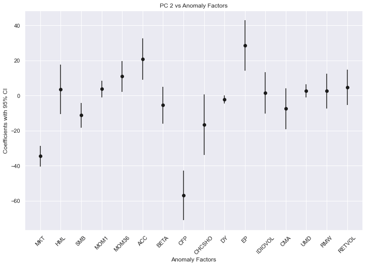

```python
pc2 = OLS_regression(y = pc_ret_rt, X = factors, y_column = "PC 2", is_pc = False)
```

```python
print(pc2.summary())
```

```
                            OLS Regression Results
==============================================================================
Dep. Variable:                   PC 2   R-squared:                       0.662
Model:                            OLS   Adj. R-squared:                  0.645
Method:                 Least Squares   F-statistic:                     37.87
Date:                Sat, 15 Jul 2023   Prob (F-statistic):           4.19e-63
Time:                        16:35:50   Log-Likelihood:                -549.10
No. Observations:                 326   AIC:                             1132.
Df Residuals:                     309   BIC:                             1197.
Df Model:                          16
Covariance Type:            nonrobust
==============================================================================
                 coef    std err          t      P>|t|      [0.025      0.975]
------------------------------------------------------------------------------
const          0.3155      0.085      3.718      0.000       0.149       0.482
MKT          -34.5536      3.006    -11.494      0.000     -40.469     -28.638
HML            3.3906      7.178      0.472      0.637     -10.733      17.514
SMB          -11.3074      3.613     -3.130      0.002     -18.417      -4.198
MOM1           3.7126      2.384      1.557      0.120      -0.979       8.404
MOM36         10.9439      4.459      2.454      0.015       2.170      19.718
ACC           20.8124      6.063      3.433      0.001       8.883      32.742
BETA          -5.5253      5.331     -1.036      0.301     -16.015       4.965
CFP          -56.8628      7.186     -7.913      0.000     -71.002     -42.724
CHCSHO       -16.7244      8.805     -1.899      0.058     -34.050       0.601
DY            -2.1662      1.156     -1.874      0.062      -4.440       0.108
EP            28.5162      7.295      3.909      0.000      14.162      42.870
IDIOVOL        1.4526      5.971      0.243      0.808     -10.296      13.201
CMA           -7.5439      5.967     -1.264      0.207     -19.286       4.198
UMD            2.6894      1.946      1.382      0.168      -1.139       6.518
RMW            2.6344      5.059      0.521      0.603      -7.320      12.589
RETVOL         4.6764      5.093      0.918      0.359      -5.344      14.697
==============================================================================
Omnibus:                      257.183   Durbin-Watson:                   1.685
Prob(Omnibus):                  0.000   Jarque-Bera (JB):            11439.574
Skew:                           2.753   Prob(JB):                         0.00
Kurtosis:                      31.493   Cond. No.                         147.
==============================================================================

Notes:
[1] Standard Errors assume that the covariance matrix of the errors is correctly specified.
```

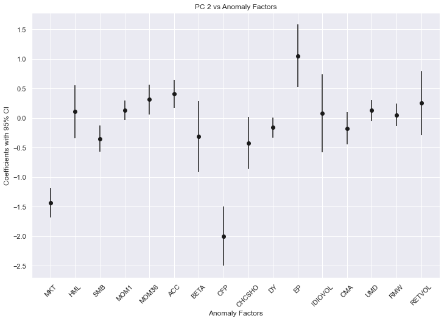

```python
pc2std = OLS_regression(y = pc_ret_rt, X = standardized_factors, y_column = "PC 2", is_pc = False)
```

```python
print(pc2std.summary())
```

```
                            OLS Regression Results
==============================================================================
Dep. Variable:                   PC 2   R-squared:                       0.662
Model:                            OLS   Adj. R-squared:                  0.645
Method:                 Least Squares   F-statistic:                     37.87
Date:                Sat, 15 Jul 2023   Prob (F-statistic):           4.19e-63
Time:                        16:35:50   Log-Likelihood:                -549.10
No. Observations:                 326   AIC:                             1132.
Df Residuals:                     309   BIC:                             1197.
Df Model:                          16
Covariance Type:            nonrobust
==============================================================================
                 coef    std err          t      P>|t|      [0.025      0.975]
------------------------------------------------------------------------------
const       4.684e-17      0.074   6.31e-16      1.000      -0.146       0.146
MKT           -1.4387      0.125    -11.494      0.000      -1.685      -1.192
HML            0.1080      0.229      0.472      0.637      -0.342       0.558
SMB           -0.3504      0.112     -3.130      0.002      -0.571      -0.130
MOM1           0.1287      0.083      1.557      0.120      -0.034       0.291
MOM36          0.3122      0.127      2.454      0.015       0.062       0.562
ACC            0.4110      0.120      3.433      0.001       0.175       0.647
BETA          -0.3153      0.304     -1.036      0.301      -0.914       0.283
CFP           -1.9972      0.252     -7.913      0.000      -2.494      -1.501
CHCSHO        -0.4201      0.221     -1.899      0.058      -0.855       0.015
DY            -0.1619      0.086     -1.874      0.062      -0.332       0.008
EP             1.0513      0.269      3.909      0.000       0.522       1.581
IDIOVOL        0.0814      0.335      0.243      0.808      -0.577       0.740
CMA           -0.1744      0.138     -1.264      0.207      -0.446       0.097
UMD            0.1274      0.092      1.382      0.168      -0.054       0.309
RMW            0.0502      0.096      0.521      0.603      -0.140       0.240
RETVOL         0.2513      0.274      0.918      0.359      -0.287       0.790
==============================================================================
Omnibus:                      257.183   Durbin-Watson:                   1.685
Prob(Omnibus):                  0.000   Jarque-Bera (JB):            11439.574
Skew:                           2.753   Prob(JB):                         0.00
Kurtosis:                      31.493   Cond. No.                         14.8
==============================================================================

Notes:
[1] Standard Errors assume that the covariance matrix of the errors is correctly specified.
```

```python
corr_matrix = round(pd.concat([pc_ret_rt, factors], axis=1).corr(), 2)
corr_matrix[factors.columns][:2]
```

|  | MKT | HML | SMB | MOM1 | MOM36 | ACC | BETA | CFP | CHCSHO | DY | EP | IDIOVOL | CMA | UMD | RMW | RETVOL |
| --- | --- | --- | --- | --- | --- | --- | --- | --- | --- | --- | --- | --- | --- | --- | --- | --- |
| PC 1 | 0.70 | -0.38 | 0.70 | 0.31 | 0.16 | 0.40 | -0.87 | -0.54 | -0.73 | -0.39 | -0.69 | -0.85 | -0.36 | -0.34 | -0.02 | -0.87 |
| PC 2 | -0.47 | -0.46 | -0.03 | -0.11 | -0.19 | 0.21 | 0.11 | -0.47 | -0.15 | -0.12 | -0.24 | 0.00 | -0.24 | 0.28 | 0.22 | 0.09 |

### (c) (30 points)

Now, run a principal component analysis on the 16 "anomaly factors" and select the optimal number of principal components using the same criterion adopted in the first item of the exercise. By inspecting the principal eigenvectors can you identify a dominating "anomaly"?

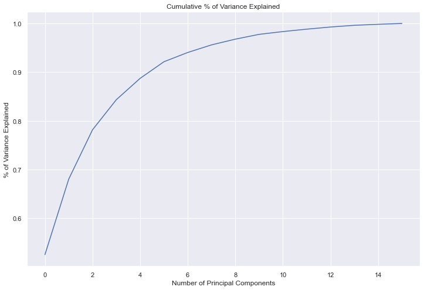

```python
pcs, gammas, lambdas, alphas = PCA_function(factors)
```

The transformed dataset containing only the first $k$ PCs is the $(T \times k)$ matrix is given by $$ \begin{aligned} Z_{(k)}&:=\boldsymbol{X} \boldsymbol{\Gamma}_k \\ &:=\left(Z_1, \ldots, Z_k\right) . \end{aligned} $$

```python
pcs
```

| dates | PC 1 | PC 2 | PC 3 | PC 4 | PC 5 | PC 6 | PC 7 | PC 8 | PC 9 | PC 10 | PC 11 | PC 12 | PC 13 | PC 14 | PC 15 | PC 16 |
| --- | --- | --- | --- | --- | --- | --- | --- | --- | --- | --- | --- | --- | --- | --- | --- | --- |
| 1991-11-29 | -0.040773 | -0.040907 | -0.034789 | -0.042608 | 0.021649 | 0.016281 | -0.002945 | 0.013785 | -0.017158 | 0.014302 | -0.000852 | -0.001911 | 0.020720 | -0.006350 | -0.001400 | 0.010884 |
| 1991-12-31 | 0.112512 | -0.012316 | -0.038009 | 0.025986 | -0.097625 | -0.067016 | 0.003296 | 0.040766 | -0.007335 | -0.038197 | -0.019778 | -0.016917 | 0.001232 | -0.004424 | 0.009337 | 0.003344 |
| 1992-01-31 | 0.121870 | 0.061630 | 0.066577 | 0.094953 | 0.039049 | 0.094894 | -0.019855 | -0.018094 | 0.027580 | -0.025830 | -0.010560 | 0.016397 | -0.015376 | 0.005044 | -0.015541 | 0.000678 |
| 1992-02-28 | -0.005106 | 0.043395 | 0.047053 | 0.084682 | 0.035254 | -0.009129 | 0.001453 | -0.009655 | 0.018775 | -0.037510 | -0.010383 | 0.011410 | -0.015339 | -0.020289 | -0.007772 | -0.006360 |
| 1992-03-31 | -0.108007 | 0.012929 | 0.026053 | 0.021665 | 0.019578 | 0.005955 | 0.008637 | -0.012087 | -0.007382 | 0.001359 | 0.014567 | -0.002389 | 0.000943 | -0.014158 | -0.008707 | 0.004097 |
| ... | ... | ... | ... | ... | ... | ... | ... | ... | ... | ... | ... | ... | ... | ... | ... | ... |
| 2018-08-31 | 0.070953 | -0.020014 | -0.064739 | -0.014552 | -0.031384 | 0.001708 | 0.000216 | 0.006447 | 0.033096 | -0.004760 | 0.005052 | 0.018721 | -0.006200 | 0.004292 | -0.008864 | 0.001477 |
| 2018-09-28 | 0.006513 | -0.057196 | 0.004248 | -0.013213 | 0.005573 | -0.003490 | 0.028139 | -0.015625 | 0.005807 | -0.002020 | 0.011408 | 0.008313 | 0.012052 | 0.007154 | 0.008874 | 0.007852 |
| 2018-10-31 | -0.167718 | -0.033319 | 0.045695 | -0.010240 | 0.027620 | 0.030816 | 0.020208 | -0.008359 | -0.036528 | -0.013421 | -0.003895 | 0.014628 | 0.007450 | 0.015891 | 0.009551 | 0.001811 |
| 2018-11-30 | -0.058530 | 0.037814 | -0.010477 | -0.049877 | -0.016665 | -0.006877 | 0.009479 | 0.020282 | 0.002731 | 0.015987 | -0.005853 | -0.003734 | 0.003878 | -0.033355 | 0.002179 | 0.006967 |
| 2018-12-31 | -0.101082 | 0.010640 | -0.083628 | -0.054505 | 0.049028 | 0.031435 | 0.002180 | -0.014540 | -0.033522 | -0.014590 | 0.010289 | 0.007399 | -0.001988 | -0.006278 | 0.006951 | -0.002352 |

326 rows × 16 columns

Given the desired number of $\mathrm{PCs}$, say $1 \leq k \leq n$, we collect all the vectors $\gamma_1, \ldots \gamma_k$ in a $(n \times k)$ matrix $$ \Gamma_k:=\left(\gamma_1, \ldots \gamma_k\right) $$

```python
gammas
```

|  | gamma 1 | gamma 2 | gamma 3 | gamma 4 | gamma 5 | gamma 6 | gamma 7 | gamma 8 | gamma 9 | gamma 10 | gamma 11 | gamma 12 | gamma 13 | gamma 14 | gamma 15 | gamma 16 |
| --- | --- | --- | --- | --- | --- | --- | --- | --- | --- | --- | --- | --- | --- | --- | --- | --- |
| MKT | 0.228449 | 0.191721 | 0.189615 | 0.091736 | -0.553227 | -0.518328 | 0.175670 | 0.206177 | 0.366554 | 0.256106 | 0.051101 | 0.050067 | 0.077697 | -0.007618 | -0.026166 | -0.082113 |
| HML | -0.154749 | 0.062009 | 0.342674 | 0.383140 | -0.006026 | 0.005076 | -0.142897 | -0.089115 | -0.183488 | 0.055659 | -0.206796 | 0.166271 | -0.298290 | -0.485828 | 0.000223 | -0.497374 |
| SMB | 0.168694 | 0.058650 | 0.028389 | 0.137712 | 0.194181 | 0.452578 | -0.387099 | 0.476201 | 0.359562 | 0.413748 | 0.098614 | -0.118879 | 0.036374 | -0.029458 | 0.003708 | -0.051500 |
| MOM1 | 0.066700 | 0.065963 | 0.211633 | -0.201040 | -0.644130 | 0.663915 | 0.070393 | -0.177102 | -0.055403 | -0.068285 | -0.038356 | 0.038325 | 0.007077 | 0.051119 | 0.024229 | -0.008108 |
| MOM36 | 0.003330 | 0.127738 | 0.096021 | 0.497916 | 0.209302 | 0.227409 | 0.441680 | -0.126307 | 0.403796 | -0.266598 | -0.173447 | 0.104123 | 0.277238 | -0.007725 | -0.226390 | 0.129423 |
| ACC | 0.081187 | 0.003743 | -0.132634 | -0.012960 | 0.050161 | 0.014296 | -0.020514 | -0.583009 | 0.320087 | 0.114583 | 0.471069 | -0.278522 | -0.261653 | 0.023746 | -0.268018 | -0.276891 |
| BETA | -0.447878 | -0.218960 | -0.081117 | -0.134744 | 0.020983 | 0.067217 | 0.129617 | 0.021959 | 0.169726 | 0.281068 | 0.209655 | 0.715301 | 0.003585 | 0.152287 | -0.061799 | -0.118512 |
| CFP | -0.204639 | 0.012831 | 0.344791 | 0.252459 | -0.054861 | -0.105223 | -0.433638 | -0.350681 | 0.138200 | 0.065442 | 0.104105 | 0.074695 | -0.035096 | 0.085521 | 0.297197 | 0.559974 |
| CHCSHO | -0.182823 | -0.029610 | 0.115116 | 0.107098 | 0.027947 | 0.004601 | 0.053857 | 0.082061 | 0.136833 | -0.291804 | 0.180776 | -0.176915 | 0.148678 | 0.360392 | 0.621447 | -0.473819 |
| DY | -0.388018 | 0.862257 | -0.301306 | -0.070640 | -0.025850 | 0.012490 | -0.094100 | 0.008833 | -0.009831 | -0.008668 | -0.014002 | -0.002232 | 0.000652 | 0.004500 | -0.002023 | -0.004943 |
| EP | -0.256139 | -0.056180 | 0.290519 | 0.065395 | -0.105811 | -0.090116 | -0.339623 | 0.191388 | -0.124651 | -0.265990 | 0.099115 | -0.109858 | 0.175222 | 0.349712 | -0.628688 | -0.121809 |
| IDIOVOL | -0.447106 | -0.141603 | 0.120198 | -0.128713 | -0.067057 | 0.024197 | 0.211033 | 0.162011 | 0.034144 | -0.005306 | 0.364339 | -0.341242 | 0.247443 | -0.580530 | 0.008382 | 0.156427 |
| CMA | -0.105896 | 0.053198 | 0.110473 | 0.264680 | -0.007434 | 0.081863 | 0.393200 | 0.296365 | -0.205872 | 0.068794 | 0.230227 | -0.137885 | -0.644137 | 0.261759 | -0.021478 | 0.226886 |
| UMD | -0.081444 | -0.254533 | -0.653139 | 0.526627 | -0.407090 | 0.031903 | -0.176837 | 0.052899 | -0.068582 | -0.093931 | 0.059701 | -0.009434 | 0.038260 | -0.065534 | 0.018467 | 0.023766 |
| RMW | 0.011606 | -0.055604 | -0.054078 | -0.243840 | -0.045945 | -0.031349 | -0.182397 | 0.216336 | 0.469514 | -0.596053 | -0.032495 | 0.159734 | -0.447973 | -0.206308 | -0.001668 | 0.075421 |
| RETVOL | -0.417622 | -0.221104 | -0.064418 | -0.106175 | -0.080566 | -0.024605 | 0.052871 | -0.070598 | 0.288356 | 0.251271 | -0.635278 | -0.379685 | -0.161098 | 0.157198 | -0.034045 | -0.023620 |

Also, by construction, the columns of $Z_{(k)}$ (the PCs) are orthogonal random variables, and with sample variances $\lambda_1, \ldots, \lambda_k$.

Thus, the sample covariance matrix of $Z_{(k)}$ is given by the $(k \times k)$ diagonal matrix $$ \boldsymbol{\Lambda}_k:=\operatorname{diag}\left(\lambda_1, \ldots, \lambda_k\right) $$

```python
lambdas[:10]
```

```
array([0.0143643 , 0.00424359, 0.00277031, 0.00168956, 0.00119888,
       0.00093209, 0.00052007, 0.00042722, 0.00032125, 0.00027015])
```

It is a good idea to start by running a full PCA $(k=n)$ and plotting the quantity $$ \alpha_j=\frac{\lambda_j}{\sum_{j=1}^n \lambda_j} $$ for $j \in\{1, \ldots, n\}$.

```python
alphas[:10]
```

```
array([0.52522946, 0.15516658, 0.10129623, 0.06177849, 0.04383691,
       0.03408185, 0.01901649, 0.01562144, 0.01174643, 0.00987803])
```

```python
Lambda = round(pcs.cov(), 4)
```

Also, by construction, the columns of $Z_{(k)}$ (the $\mathrm{PCs}$) are orthogonal random variables, and with sample variances $\lambda_1, \ldots, \lambda_k$. Thus, the sample covariance matrix of $Z_{(k)}$ is given by the $(k \times k)$ diagonal matrix $$ \boldsymbol{\Lambda}_k:=\operatorname{diag}\left(\lambda_1, \ldots, \lambda_k\right) . $$

```python
Lambda.head(10)[['PC 1', 'PC 2', 'PC 3', 'PC 4', 'PC 5', 'PC 6', 'PC 7', 'PC 8', 'PC 9', 'PC 10']]
```

|  | PC 1 | PC 2 | PC 3 | PC 4 | PC 5 | PC 6 | PC 7 | PC 8 | PC 9 | PC 10 |
| --- | --- | --- | --- | --- | --- | --- | --- | --- | --- | --- |
| PC 1 | 0.0144 | 0.0000 | 0.0000 | 0.0000 | -0.0000 | -0.0000 | 0.0000 | 0.0000 | 0.0000 | 0.0000 |
| PC 2 | 0.0000 | 0.0042 | 0.0000 | 0.0000 | -0.0000 | 0.0000 | -0.0000 | 0.0000 | -0.0000 | -0.0000 |
| PC 3 | 0.0000 | 0.0000 | 0.0028 | -0.0000 | 0.0000 | -0.0000 | -0.0000 | -0.0000 | -0.0000 | -0.0000 |
| PC 4 | 0.0000 | 0.0000 | -0.0000 | 0.0017 | 0.0000 | 0.0000 | -0.0000 | -0.0000 | 0.0000 | 0.0000 |
| PC 5 | -0.0000 | -0.0000 | 0.0000 | 0.0000 | 0.0012 | -0.0000 | 0.0000 | -0.0000 | -0.0000 | -0.0000 |
| PC 6 | -0.0000 | 0.0000 | -0.0000 | 0.0000 | -0.0000 | 0.0009 | 0.0000 | 0.0000 | 0.0000 | 0.0000 |
| PC 7 | 0.0000 | -0.0000 | -0.0000 | -0.0000 | 0.0000 | 0.0000 | 0.0005 | 0.0000 | -0.0000 | -0.0000 |
| PC 8 | 0.0000 | 0.0000 | -0.0000 | -0.0000 | -0.0000 | 0.0000 | 0.0000 | 0.0004 | 0.0000 | 0.0000 |
| PC 9 | 0.0000 | -0.0000 | -0.0000 | 0.0000 | -0.0000 | 0.0000 | -0.0000 | 0.0000 | 0.0003 | 0.0000 |
| PC 10 | 0.0000 | -0.0000 | -0.0000 | 0.0000 | -0.0000 | 0.0000 | -0.0000 | 0.0000 | 0.0000 | 0.0003 |

```python
lambdas[:10]
```

```
array([0.0143643 , 0.00424359, 0.00277031, 0.00168956, 0.00119888,
       0.00093209, 0.00052007, 0.00042722, 0.00032125, 0.00027015])
```

#### Rule of Thumb

Stop at a $k$ such that the $(k+1)$-th PC does not add much to the already explained variance (say $<3 \%$ ).

```python
n_pc_rt = rule_thumb(alphas)
```

```
The first 6 PCs explain 92.14% of the returns variance.
```

#### Informal Way

Choose the number of components such that a large portion (say 90\%) of the variance is explained.

```python
n_pc_iw = informal_way(alphas)
```

```
The first 5 PCs explain 88.73% of the returns variance.
```

#### Biggest Drop

Onatski (2010) suggests looking for the biggest drop computing $$ r:=\arg \max _{1 \leq j<n} \frac{\lambda_j}{\lambda_{j+1}} . $$

```python
n_pc_bd = biggest_drop(lambdas)
```

```
The first 1 PCs explain 52.52% of the returns variance.
```

```python
# rule of thumb
pc_fac_rt = pcs.iloc[:,:n_pc_rt]
pc_fac_rt.head()
```

| dates | PC 1 | PC 2 | PC 3 | PC 4 | PC 5 | PC 6 |
| --- | --- | --- | --- | --- | --- | --- |
| 1991-11-29 | -0.040773 | -0.040907 | -0.034789 | -0.042608 | 0.021649 | 0.016281 |
| 1991-12-31 | 0.112512 | -0.012316 | -0.038009 | 0.025986 | -0.097625 | -0.067016 |
| 1992-01-31 | 0.121870 | 0.061630 | 0.066577 | 0.094953 | 0.039049 | 0.094894 |
| 1992-02-28 | -0.005106 | 0.043395 | 0.047053 | 0.084682 | 0.035254 | -0.009129 |
| 1992-03-31 | -0.108007 | 0.012929 | 0.026053 | 0.021665 | 0.019578 | 0.005955 |

By inspecting the principal eigenvectors can you identify a dominating anomaly?

```python
gammas
```

|  | gamma 1 | gamma 2 | gamma 3 | gamma 4 | gamma 5 | gamma 6 | gamma 7 | gamma 8 | gamma 9 | gamma 10 | gamma 11 | gamma 12 | gamma 13 | gamma 14 | gamma 15 | gamma 16 |
| --- | --- | --- | --- | --- | --- | --- | --- | --- | --- | --- | --- | --- | --- | --- | --- | --- |
| MKT | 0.228449 | 0.191721 | 0.189615 | 0.091736 | -0.553227 | -0.518328 | 0.175670 | 0.206177 | 0.366554 | 0.256106 | 0.051101 | 0.050067 | 0.077697 | -0.007618 | -0.026166 | -0.082113 |
| HML | -0.154749 | 0.062009 | 0.342674 | 0.383140 | -0.006026 | 0.005076 | -0.142897 | -0.089115 | -0.183488 | 0.055659 | -0.206796 | 0.166271 | -0.298290 | -0.485828 | 0.000223 | -0.497374 |
| SMB | 0.168694 | 0.058650 | 0.028389 | 0.137712 | 0.194181 | 0.452578 | -0.387099 | 0.476201 | 0.359562 | 0.413748 | 0.098614 | -0.118879 | 0.036374 | -0.029458 | 0.003708 | -0.051500 |
| MOM1 | 0.066700 | 0.065963 | 0.211633 | -0.201040 | -0.644130 | 0.663915 | 0.070393 | -0.177102 | -0.055403 | -0.068285 | -0.038356 | 0.038325 | 0.007077 | 0.051119 | 0.024229 | -0.008108 |
| MOM36 | 0.003330 | 0.127738 | 0.096021 | 0.497916 | 0.209302 | 0.227409 | 0.441680 | -0.126307 | 0.403796 | -0.266598 | -0.173447 | 0.104123 | 0.277238 | -0.007725 | -0.226390 | 0.129423 |
| ACC | 0.081187 | 0.003743 | -0.132634 | -0.012960 | 0.050161 | 0.014296 | -0.020514 | -0.583009 | 0.320087 | 0.114583 | 0.471069 | -0.278522 | -0.261653 | 0.023746 | -0.268018 | -0.276891 |
| BETA | -0.447878 | -0.218960 | -0.081117 | -0.134744 | 0.020983 | 0.067217 | 0.129617 | 0.021959 | 0.169726 | 0.281068 | 0.209655 | 0.715301 | 0.003585 | 0.152287 | -0.061799 | -0.118512 |
| CFP | -0.204639 | 0.012831 | 0.344791 | 0.252459 | -0.054861 | -0.105223 | -0.433638 | -0.350681 | 0.138200 | 0.065442 | 0.104105 | 0.074695 | -0.035096 | 0.085521 | 0.297197 | 0.559974 |
| CHCSHO | -0.182823 | -0.029610 | 0.115116 | 0.107098 | 0.027947 | 0.004601 | 0.053857 | 0.082061 | 0.136833 | -0.291804 | 0.180776 | -0.176915 | 0.148678 | 0.360392 | 0.621447 | -0.473819 |
| DY | -0.388018 | 0.862257 | -0.301306 | -0.070640 | -0.025850 | 0.012490 | -0.094100 | 0.008833 | -0.009831 | -0.008668 | -0.014002 | -0.002232 | 0.000652 | 0.004500 | -0.002023 | -0.004943 |
| EP | -0.256139 | -0.056180 | 0.290519 | 0.065395 | -0.105811 | -0.090116 | -0.339623 | 0.191388 | -0.124651 | -0.265990 | 0.099115 | -0.109858 | 0.175222 | 0.349712 | -0.628688 | -0.121809 |
| IDIOVOL | -0.447106 | -0.141603 | 0.120198 | -0.128713 | -0.067057 | 0.024197 | 0.211033 | 0.162011 | 0.034144 | -0.005306 | 0.364339 | -0.341242 | 0.247443 | -0.580530 | 0.008382 | 0.156427 |
| CMA | -0.105896 | 0.053198 | 0.110473 | 0.264680 | -0.007434 | 0.081863 | 0.393200 | 0.296365 | -0.205872 | 0.068794 | 0.230227 | -0.137885 | -0.644137 | 0.261759 | -0.021478 | 0.226886 |
| UMD | -0.081444 | -0.254533 | -0.653139 | 0.526627 | -0.407090 | 0.031903 | -0.176837 | 0.052899 | -0.068582 | -0.093931 | 0.059701 | -0.009434 | 0.038260 | -0.065534 | 0.018467 | 0.023766 |
| RMW | 0.011606 | -0.055604 | -0.054078 | -0.243840 | -0.045945 | -0.031349 | -0.182397 | 0.216336 | 0.469514 | -0.596053 | -0.032495 | 0.159734 | -0.447973 | -0.206308 | -0.001668 | 0.075421 |
| RETVOL | -0.417622 | -0.221104 | -0.064418 | -0.106175 | -0.080566 | -0.024605 | 0.052871 | -0.070598 | 0.288356 | 0.251271 | -0.635278 | -0.379685 | -0.161098 | 0.157198 | -0.034045 | -0.023620 |

```python
sum(round(centered_factors.dot(np.array(gammas["gamma 1"])), 10) == round(pcs["PC 1"], 10))
```

```
326
```

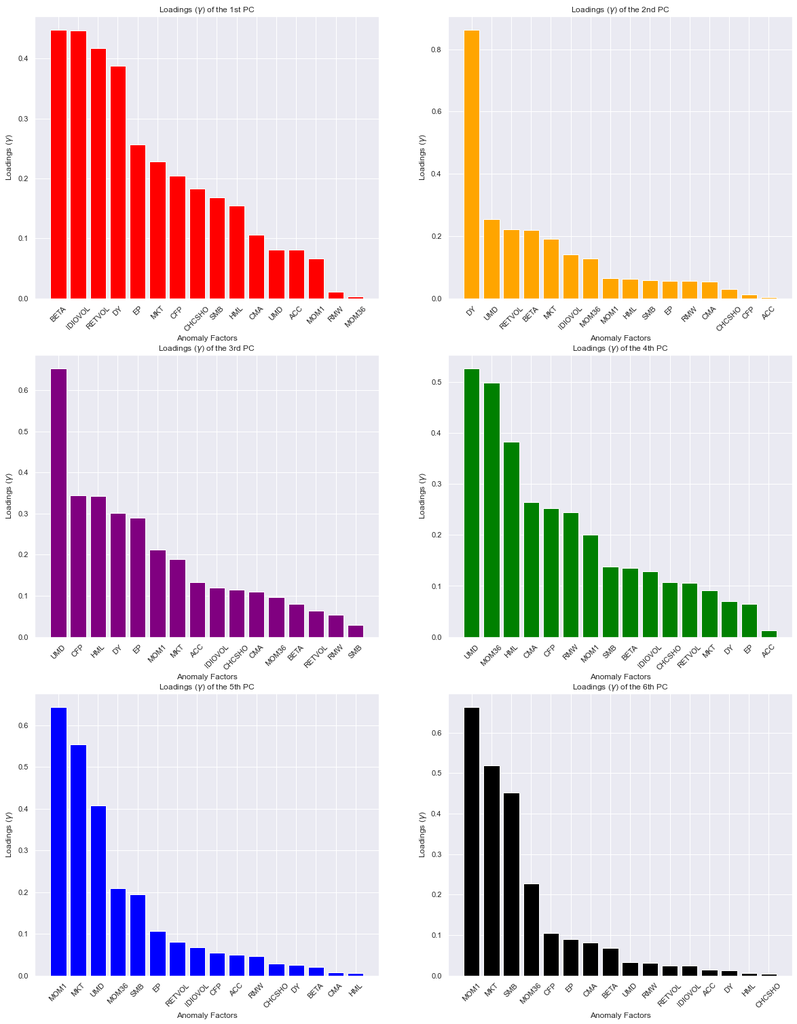

```python
fig, ax = plt.subplots(nrows=3, ncols=2, figsize=(20, 26))

aux1 = gammas["gamma 1"].abs().sort_values(ascending=False)
ax[0,0].bar(aux1.index, aux1.values, color='red')
ax[0,0].tick_params(axis='x', rotation=45)
ax[0,0].set_xlabel('Anomaly Factors')
ax[0,0].set_ylabel('Loadings ($\gamma$)')
ax[0,0].set_title(f'Loadings ($\gamma$) of the 1st PC');

aux2 = gammas["gamma 2"].abs().sort_values(ascending=False)
ax[0,1].bar(aux2.index, aux2.values, color='orange')
ax[0,1].tick_params(axis='x', rotation=45)
ax[0,1].set_xlabel('Anomaly Factors')
ax[0,1].set_ylabel('Loadings ($\gamma$)')
ax[0,1].set_title(f'Loadings ($\gamma$) of the 2nd PC');

aux3 = gammas["gamma 3"].abs().sort_values(ascending=False)
ax[1,0].bar(aux3.index, aux3.values, color='purple')
ax[1,0].tick_params(axis='x', rotation=45)
ax[1,0].set_xlabel('Anomaly Factors')
ax[1,0].set_ylabel('Loadings ($\gamma$)')
ax[1,0].set_title(f'Loadings ($\gamma$) of the 3rd PC');

aux4 = gammas["gamma 4"].abs().sort_values(ascending=False)
ax[1,1].bar(aux4.index, aux4.values, color='green')
ax[1,1].tick_params(axis='x', rotation=45)
ax[1,1].set_xlabel('Anomaly Factors')
ax[1,1].set_ylabel('Loadings ($\gamma$)')
ax[1,1].set_title(f'Loadings ($\gamma$) of the 4th PC');

aux5 = gammas["gamma 5"].abs().sort_values(ascending=False)
ax[2,0].bar(aux5.index, aux5.values, color='blue')
ax[2,0].tick_params(axis='x', rotation=45)
ax[2,0].set_xlabel('Anomaly Factors')
ax[2,0].set_ylabel('Loadings ($\gamma$)')
ax[2,0].set_title(f'Loadings ($\gamma$) of the 5th PC');

aux6 = gammas["gamma 6"].abs().sort_values(ascending=False)
ax[2,1].bar(aux6.index, aux6.values, color='black')
ax[2,1].tick_params(axis='x', rotation=45)
ax[2,1].set_xlabel('Anomaly Factors')
ax[2,1].set_ylabel('Loadings ($\gamma$)')
ax[2,1].set_title(f'Loadings ($\gamma$) of the 6th PC');
```

```python
gammas["gamma 1"]
```

```
MKT        0.228449
HML       -0.154749
SMB        0.168694
MOM1       0.066700
MOM36      0.003330
ACC        0.081187
BETA      -0.447878
CFP       -0.204639
CHCSHO    -0.182823
DY        -0.388018
EP        -0.256139
IDIOVOL   -0.447106
CMA       -0.105896
UMD       -0.081444
RMW        0.011606
RETVOL    -0.417622
Name: gamma 1, dtype: float64
```

```python
(gammas["gamma 1"].abs()).nlargest(2)
```

```
BETA       0.447878
IDIOVOL    0.447106
Name: gamma 1, dtype: float64
```

```python
(gammas["gamma 1"].abs()).nsmallest(2)
```

```
MOM36    0.003330
RMW      0.011606
Name: gamma 1, dtype: float64
```

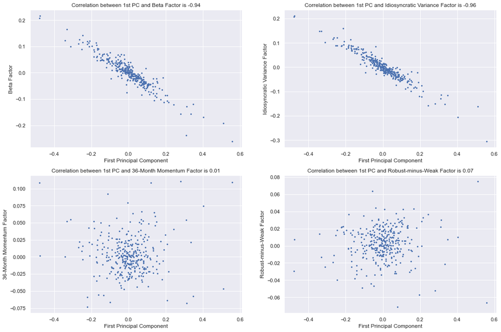

```python
fig, ax = plt.subplots(nrows=2, ncols=2, figsize=(18, 12))

corr_1 = round(factors['BETA'].corr(pc_fac_rt['PC 1']), 2)
ax[0,0].scatter(pc_fac_rt['PC 1'], factors['BETA'], s=5)
ax[0,0].set_xlabel('First Principal Component')
ax[0,0].set_ylabel('Beta Factor')
ax[0,0].set_title(f'Correlation between 1st PC and Beta Factor is {corr_1}');

corr_2 = round(factors['IDIOVOL'].corr(pc_fac_rt['PC 1']), 2)
ax[0,1].scatter(pc_fac_rt['PC 1'], factors['IDIOVOL'], s=5)
ax[0,1].set_xlabel('First Principal Component')
ax[0,1].set_ylabel('Idiosyncratic Variance Factor')
ax[0,1].set_title(f'Correlation between 1st PC and Idiosyncratic Variance Factor is {corr_2}');

corr_3 = round(factors['MOM36'].corr(pc_fac_rt['PC 1']), 2)
ax[1,0].scatter(pc_fac_rt['PC 1'], factors['MOM36'], s=5)
ax[1,0].set_xlabel('First Principal Component')
ax[1,0].set_ylabel('36-Month Momentum Factor')
ax[1,0].set_title(f'Correlation between 1st PC and 36-Month Momentum Factor is {corr_3}');

corr_4 = round(factors['RMW'].corr(pc_fac_rt['PC 1']), 2)
ax[1,1].scatter(pc_fac_rt['PC 1'], factors['RMW'], s=5)
ax[1,1].set_xlabel('First Principal Component')
ax[1,1].set_ylabel('Robust-minus-Weak Factor')
ax[1,1].set_title(f'Correlation between 1st PC and Robust-minus-Weak Factor is {corr_4}');
```

### (d) (30 points)

How do the "anomaly-based principal factors" related to the "return-based principal factors"?

```python
pc_ret_rt.head()
```

| dates | PC 1 | PC 2 |
| --- | --- | --- |
| 1991-11-29 | -0.932311 | 0.655585 |
| 1991-12-31 | 0.684426 | -0.766075 |
| 1992-01-31 | 2.223682 | -0.458117 |
| 1992-02-28 | 0.562873 | -0.140579 |
| 1992-03-31 | -0.743650 | 0.306019 |

```python
pc_fac_rt.head()
```

| dates | PC 1 | PC 2 | PC 3 | PC 4 | PC 5 | PC 6 |
| --- | --- | --- | --- | --- | --- | --- |
| 1991-11-29 | -0.040773 | -0.040907 | -0.034789 | -0.042608 | 0.021649 | 0.016281 |
| 1991-12-31 | 0.112512 | -0.012316 | -0.038009 | 0.025986 | -0.097625 | -0.067016 |
| 1992-01-31 | 0.121870 | 0.061630 | 0.066577 | 0.094953 | 0.039049 | 0.094894 |
| 1992-02-28 | -0.005106 | 0.043395 | 0.047053 | 0.084682 | 0.035254 | -0.009129 |
| 1992-03-31 | -0.108007 | 0.012929 | 0.026053 | 0.021665 | 0.019578 | 0.005955 |

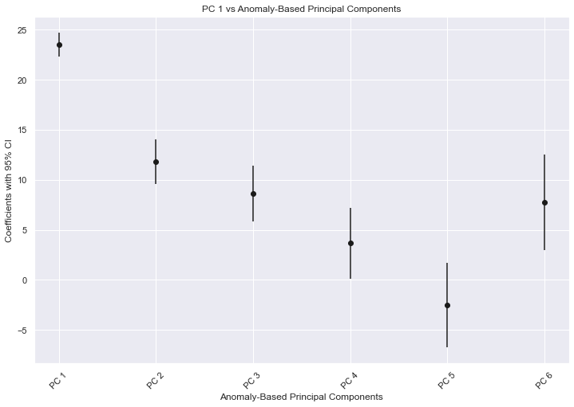

```python
pc1 = OLS_regression(y = pc_ret_rt, X = pc_fac_rt, y_column = "PC 1", is_pc = True)
```

```python
print(pc1.summary())
```

```
                            OLS Regression Results
==============================================================================
Dep. Variable:                   PC 1   R-squared:                       0.834
Model:                            OLS   Adj. R-squared:                  0.831
Method:                 Least Squares   F-statistic:                     268.0
Date:                Sat, 15 Jul 2023   Prob (F-statistic):          2.33e-121
Time:                        17:02:03   Log-Likelihood:                -553.61
No. Observations:                 326   AIC:                             1121.
Df Residuals:                     319   BIC:                             1148.
Df Model:                           6
Covariance Type:            nonrobust
==============================================================================
                 coef    std err          t      P>|t|      [0.025      0.975]
------------------------------------------------------------------------------
const      -1.162e-16      0.074  -1.57e-15      1.000      -0.146       0.146
PC 1          23.5303      0.619     38.038      0.000      22.313      24.747
PC 2          11.8198      1.138     10.385      0.000       9.581      14.059
PC 3           8.6444      1.409      6.137      0.000       5.873      11.416
PC 4           3.6781      1.804      2.039      0.042       0.129       7.227
PC 5          -2.5226      2.141     -1.178      0.240      -6.735       1.690
PC 6           7.7491      2.428      3.191      0.002       2.971      12.527
==============================================================================
Omnibus:                      171.684   Durbin-Watson:                   1.764
Prob(Omnibus):                  0.000   Jarque-Bera (JB):             2422.522
Skew:                           1.820   Prob(JB):                         0.00
Kurtosis:                      15.849   Cond. No.                         32.8
==============================================================================

Notes:
[1] Standard Errors assume that the covariance matrix of the errors is correctly specified.
```

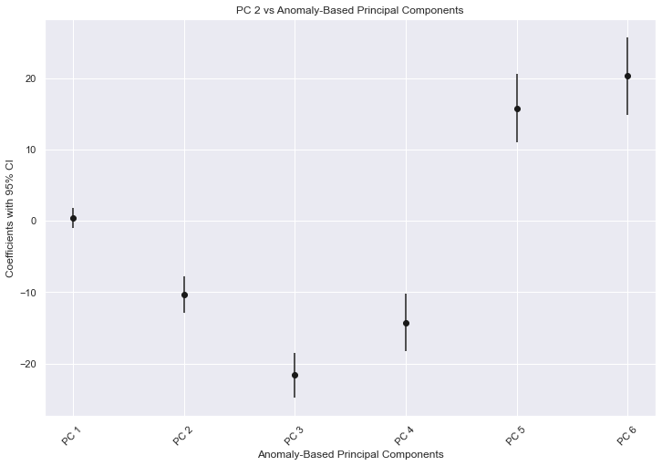

```python
pc2 = OLS_regression(y = pc_ret_rt, X = pc_fac_rt, y_column = "PC 2", is_pc = True)
```

```python
print(pc2.summary())
```

```
                            OLS Regression Results
==============================================================================
Dep. Variable:                   PC 2   R-squared:                       0.550
Model:                            OLS   Adj. R-squared:                  0.542
Method:                 Least Squares   F-statistic:                     65.07
Date:                Sat, 15 Jul 2023   Prob (F-statistic):           1.72e-52
Time:                        17:02:05   Log-Likelihood:                -595.75
No. Observations:                 326   AIC:                             1206.
Df Residuals:                     319   BIC:                             1232.
Df Model:                           6
Covariance Type:            nonrobust
==============================================================================
                 coef    std err          t      P>|t|      [0.025      0.975]
------------------------------------------------------------------------------
const       4.684e-17      0.084   5.56e-16      1.000      -0.166       0.166
PC 1           0.3608      0.704      0.513      0.609      -1.024       1.746
PC 2         -10.3232      1.295     -7.971      0.000     -12.871      -7.775
PC 3         -21.6396      1.603    -13.500      0.000     -24.793     -18.486
PC 4         -14.2854      2.053     -6.960      0.000     -18.324     -10.247
PC 5          15.7840      2.437      6.478      0.000      10.990      20.578
PC 6          20.3048      2.764      7.347      0.000      14.868      25.742
==============================================================================
Omnibus:                      233.976   Durbin-Watson:                   1.704
Prob(Omnibus):                  0.000   Jarque-Bera (JB):             7600.490
Skew:                           2.480   Prob(JB):                         0.00
Kurtosis:                      26.129   Cond. No.                         32.8
==============================================================================

Notes:
[1] Standard Errors assume that the covariance matrix of the errors is correctly specified.
```

```python
pc_ret_rt.rename(columns={'PC 1': 'PC 1 (returns)', 'PC 2': 'PC 2 (returns)'}, inplace=True)
pc_fac_rt.rename(columns={'PC 1': 'PC 1 (factors)', 'PC 2': 'PC 2 (factors)', 'PC 3': 'PC 3 (factors)', 'PC 4': 'PC 4 (factors)', 'PC 5': 'PC 5 (factors)', 'PC 6': 'PC 6 (factors)'}, inplace=True)
```

```python
corr_matrix2 = round(pd.concat([pc_ret_rt, pc_fac_rt], axis=1).corr(), 2)
corr_matrix2[pc_fac_rt.columns][:2]
```

|  | PC 1 (factors) | PC 2 (factors) | PC 3 (factors) | PC 4 (factors) | PC 5 (factors) | PC 6 (factors) |
| --- | --- | --- | --- | --- | --- | --- |
| PC 1 (returns) | 0.87 | 0.24 | 0.14 | 0.05 | -0.03 | 0.07 |
| PC 2 (returns) | 0.02 | -0.30 | -0.51 | -0.26 | 0.24 | 0.28 |